# Figures’ note

Yuta Suzuki

05 January, 2022

# Article information

Temporal dynamics of auditory bistable perception correlated with a fluctuation of baseline pupil size

Yuta Suzuki, Hsin-I Liao, Shigeto Furukawa

NTT Communication Science Laboratories, NTT Corporation, Atsugi 243-0198, Japan

*Corresponding author: Yuta Suzuki NTT Communication Science Laboratories, NTT Corporation, Atsugi 243-0198, Japan Tel: +81-046-240-3525, E-mail: yuuta.suzuki.fc@hco.ntt.co.jp

# Figure 1 Procedure

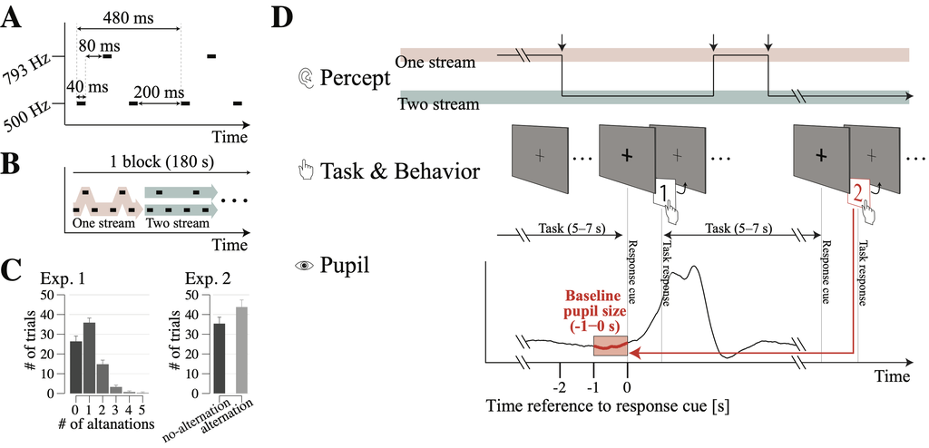

Fig. 1. Experimental design. (A) Time configuration of the ABA_ pattern. (B) Consecutive auditory tone sequences which can produce two different patterns of a single galloping or two isolated rhythms. (C) Averaged trial numbers among responses in Experiments 1 and 2 (D) Participants listened to a series of two tones with different frequencies (see ‘Methods’). Participants were asked to count the number of perceptual alternations in Experiment 1 (i.e., number of black arrows in top panel; the trace here is an example for explanation purposes) or report whether they experienced a perceptual alternation in Experiment 2 while a narrow fixation cross was presented. Once the fixation cross became thicker (i.e., response cue), participants pressed a corresponding button depending on the task (i.e., number keys from 0 to 5 in Experiment 1 and yes/no in Experiment 2). All pupil changes illustrated here are averaged data across participants and alternation cases from Experiment 1. To avoid the effect of the motor responses (i.e., button press) or its preparation on the pupil size, the baseline pupil size was defined as the mean pupil size over -1000 to 0 ms to the response cue onset (period marked in red in the graph), and was labeled according to the subsequent participants’ task answer (the red line with arrows) for subsequent baseline pupil size and cross-correlation analysis.

# figure 2 Exp.1

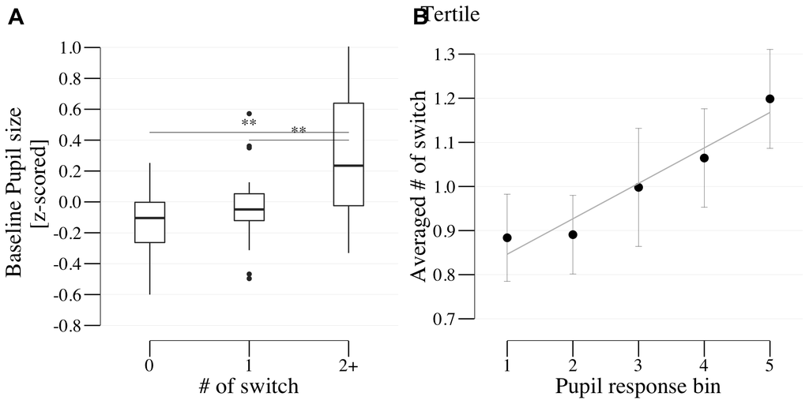

Fig. 2. Baseline pupil size in the number of perceptual alternations. (A) Averaged baseline pupil size from -1000 ms to the response cue onset (see ‘Methods’). (B) Relationship between baseline pupil size and number of perceptual alternations classified by equal size bins. Asterisks (*) indicate statistical significance at* p<0.05, and **p<0.01. Error bars indicate the standard error of the mean.

# figure 3 Exp.2

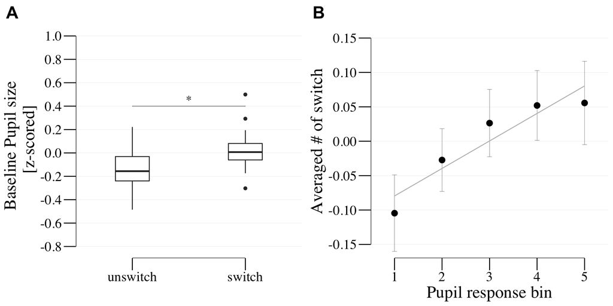

Fig. 3. Results of Experiment 2. (A) Averaged baseline pupil size from -1000 ms to the response cue onset (see ‘Methods’). (B) Relationship between baseline pupil size and probability of perceptual alternation classified by equal size bins. The asterisk (*) indicates statistical significance at p < 0.05. Error bars indicate the standard error of the mean.

# figure 4 PDPC events

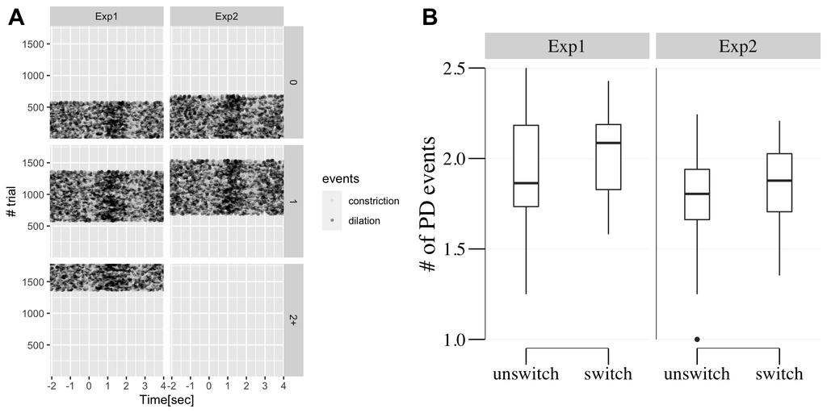

# Figure 5 Cross-corr

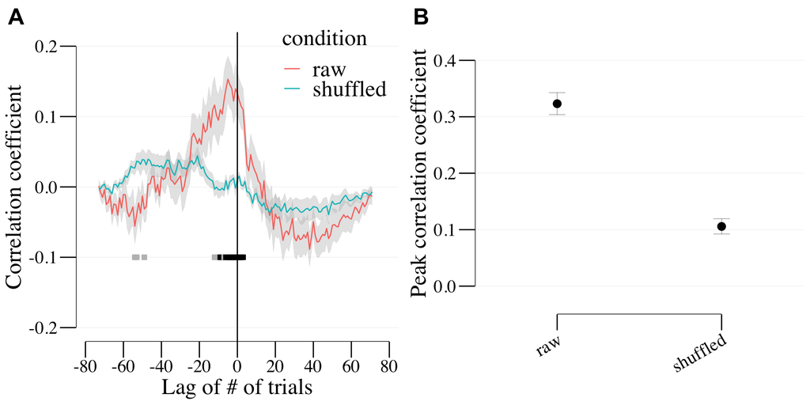